# (Prosper Loan Dataset)

## Preliminary Wrangling

The Prosper Loan Dataset consists of 113,937 loans (observation) with 81 variables on each loan, including loan amount, borrower rate (or interest rate), current loan status, borrower income, and many others.

```python
# import all packages and set plots to be embedded inline
import numpy as np
import pandas as pd
import matplotlib.pyplot as plt
import seaborn as sb

%matplotlib inline
```

```python
df=pd.read_csv('prosperLoanData.csv')
df.head()
```

|  | ListingKey | ListingNumber | ListingCreationDate | CreditGrade | Term | LoanStatus | ClosedDate | BorrowerAPR | BorrowerRate | LenderYield | ... | LP_ServiceFees | LP_CollectionFees | LP_GrossPrincipalLoss | LP_NetPrincipalLoss | LP_NonPrincipalRecoverypayments | PercentFunded | Recommendations | InvestmentFromFriendsCount | InvestmentFromFriendsAmount | Investors |
| --- | --- | --- | --- | --- | --- | --- | --- | --- | --- | --- | --- | --- | --- | --- | --- | --- | --- | --- | --- | --- | --- |
| 0 | 1021339766868145413AB3B | 193129 | 2007-08-26 19:09:29.263000000 | C | 36 | Completed | 2009-08-14 00:00:00 | 0.16516 | 0.1580 | 0.1380 | ... | -133.18 | 0.0 | 0.0 | 0.0 | 0.0 | 1.0 | 0 | 0 | 0.0 | 258 |
| 1 | 10273602499503308B223C1 | 1209647 | 2014-02-27 08:28:07.900000000 | NaN | 36 | Current | NaN | 0.12016 | 0.0920 | 0.0820 | ... | 0.00 | 0.0 | 0.0 | 0.0 | 0.0 | 1.0 | 0 | 0 | 0.0 | 1 |
| 2 | 0EE9337825851032864889A | 81716 | 2007-01-05 15:00:47.090000000 | HR | 36 | Completed | 2009-12-17 00:00:00 | 0.28269 | 0.2750 | 0.2400 | ... | -24.20 | 0.0 | 0.0 | 0.0 | 0.0 | 1.0 | 0 | 0 | 0.0 | 41 |
| 3 | 0EF5356002482715299901A | 658116 | 2012-10-22 11:02:35.010000000 | NaN | 36 | Current | NaN | 0.12528 | 0.0974 | 0.0874 | ... | -108.01 | 0.0 | 0.0 | 0.0 | 0.0 | 1.0 | 0 | 0 | 0.0 | 158 |
| 4 | 0F023589499656230C5E3E2 | 909464 | 2013-09-14 18:38:39.097000000 | NaN | 36 | Current | NaN | 0.24614 | 0.2085 | 0.1985 | ... | -60.27 | 0.0 | 0.0 | 0.0 | 0.0 | 1.0 | 0 | 0 | 0.0 | 20 |

5 rows × 81 columns

```python
df.shape
```

```
(113937, 81)
```

The Dataset consists of 113937 observations and 81 variable

```python
columns_interest=['Term','LoanStatus','BorrowerAPR','BorrowerRate','ProsperRating (numeric)','ProsperScore','EmploymentStatus','IsBorrowerHomeowner','OpenCreditLines','BankcardUtilization']
filtered_df=df[columns_interest]
```

In the previous cell we have chosen only the columns of interest from the 81 variables in the dataset

```python
filtered_df.head()
```

|  | Term | LoanStatus | BorrowerAPR | BorrowerRate | ProsperRating (numeric) | ProsperScore | EmploymentStatus | IsBorrowerHomeowner | OpenCreditLines | BankcardUtilization |
| --- | --- | --- | --- | --- | --- | --- | --- | --- | --- | --- |
| 0 | 36 | Completed | 0.16516 | 0.1580 | NaN | NaN | Self-employed | True | 4.0 | 0.00 |
| 1 | 36 | Current | 0.12016 | 0.0920 | 6.0 | 7.0 | Employed | False | 14.0 | 0.21 |
| 2 | 36 | Completed | 0.28269 | 0.2750 | NaN | NaN | Not available | False | NaN | NaN |
| 3 | 36 | Current | 0.12528 | 0.0974 | 6.0 | 9.0 | Employed | True | 5.0 | 0.04 |
| 4 | 36 | Current | 0.24614 | 0.2085 | 3.0 | 4.0 | Employed | True | 19.0 | 0.81 |

```python
filtered_df.info()
```

```
<class 'pandas.core.frame.DataFrame'>
RangeIndex: 113937 entries, 0 to 113936
Data columns (total 10 columns):
 #   Column                   Non-Null Count   Dtype
---  ------                   --------------   -----
 0   Term                     113937 non-null  int64
 1   LoanStatus               113937 non-null  object
 2   BorrowerAPR              113912 non-null  float64
 3   BorrowerRate             113937 non-null  float64
 4   ProsperRating (numeric)  84853 non-null   float64
 5   ProsperScore             84853 non-null   float64
 6   EmploymentStatus         111682 non-null  object
 7   IsBorrowerHomeowner      113937 non-null  bool
 8   OpenCreditLines          106333 non-null  float64
 9   BankcardUtilization      106333 non-null  float64
dtypes: bool(1), float64(6), int64(1), object(2)
memory usage: 7.9+ MB
```

We can see that there are some nulls in some variables

```python
filtered_df.dropna(inplace=True);
filtered_df.info();
```

```
<class 'pandas.core.frame.DataFrame'>
Int64Index: 84853 entries, 1 to 113936
Data columns (total 10 columns):
 #   Column                   Non-Null Count  Dtype
---  ------                   --------------  -----
 0   Term                     84853 non-null  int64
 1   LoanStatus               84853 non-null  object
 2   BorrowerAPR              84853 non-null  float64
 3   BorrowerRate             84853 non-null  float64
 4   ProsperRating (numeric)  84853 non-null  float64
 5   ProsperScore             84853 non-null  float64
 6   EmploymentStatus         84853 non-null  object
 7   IsBorrowerHomeowner      84853 non-null  bool
 8   OpenCreditLines          84853 non-null  float64
 9   BankcardUtilization      84853 non-null  float64
dtypes: bool(1), float64(6), int64(1), object(2)
memory usage: 6.6+ MB
```

```python
print(sum(filtered_df.duplicated()))
```

```
1327
```

We founded that there are 1327 duplicated entry in the filtered dataset

```python
filtered_df.drop_duplicates(inplace=True);
filtered_df.info();
```

```
<class 'pandas.core.frame.DataFrame'>
Int64Index: 83526 entries, 1 to 113936
Data columns (total 10 columns):
 #   Column                   Non-Null Count  Dtype
---  ------                   --------------  -----
 0   Term                     83526 non-null  int64
 1   LoanStatus               83526 non-null  object
 2   BorrowerAPR              83526 non-null  float64
 3   BorrowerRate             83526 non-null  float64
 4   ProsperRating (numeric)  83526 non-null  float64
 5   ProsperScore             83526 non-null  float64
 6   EmploymentStatus         83526 non-null  object
 7   IsBorrowerHomeowner      83526 non-null  bool
 8   OpenCreditLines          83526 non-null  float64
 9   BankcardUtilization      83526 non-null  float64
dtypes: bool(1), float64(6), int64(1), object(2)
memory usage: 6.5+ MB
```

We also removed all the duplicated rows in our filtered dataset

### What is the structure of your dataset?

> This dataset consists of 81 variable and 113937 observations

### What is/are the main feature(s) of interest in your dataset?

> The main features of interests are the ProsperScore and also the Prosper Rating

### What features in the dataset do you think will help support your investigation into your feature(s) of interest?

> From my understanding of the dataset I have chosen some variable to support me in my investigation such as Term ,LoanStatus ,BorrowerAPR ,BorrowerRate ,EmploymentStatus ,IsBorrowerHomeowner ,OpenCreditLines ,BankcardUtilization

## Univariate Exploration

```
' Here we are first getting the counts for each unique value in the employment status then we are dividing it on the\ntotal employment status to get the propotion for each unique value in the employment status as shown in the figure '
```

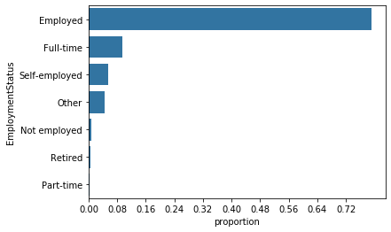

```python
base_color = sb.color_palette()[0]

employmentStat = filtered_df['EmploymentStatus'].value_counts()
total_emp_stat = filtered_df['EmploymentStatus'].value_counts().sum()
#print(total_emp_stat)
max_prop=employmentStat[0]/total_emp_stat
#print(max_prop)
tick_props = np.arange(0, max_prop, 0.08)
tick_names = ['{:0.2f}'.format(v) for v in tick_props]

sb.countplot(data=filtered_df, y='EmploymentStatus',color=base_color,order=employmentStat.index);
plt.xticks(tick_props * total_emp_stat, tick_names)
plt.xlabel('proportion');

""" Here we are first getting the counts for each unique value in the employment status then we are dividing it on the
total employment status to get the propotion for each unique value in the employment status as shown in the figure """
```

From The fiqure above we can see that most of the employment status of people is Employed status as it has a proportion of about 80% from the overall Employment status

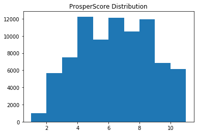

```python
plt.hist(data = filtered_df, x = 'ProsperScore');
plt.title("ProsperScore Distribution");
```

From the above histogram we can see the distribution of the Prosper score which almost looks as a multimodal distribution because it has 3 peeks

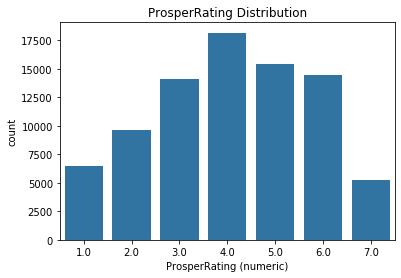

```python
sb.countplot(data=filtered_df, x='ProsperRating (numeric)', color=base_color);
plt.title("ProsperRating Distribution");
```

We can see from the figure that the prosper rating distribution almost looks like a normal distribution where the most frequent Prosper rating at rating number 4

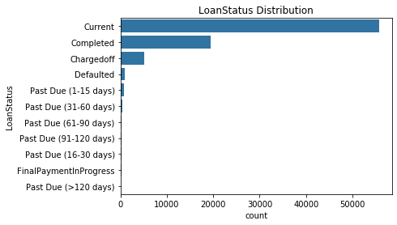

```python
loanState=employmentStat = filtered_df['LoanStatus'].value_counts()
sb.countplot(data=filtered_df, y='LoanStatus', color=base_color,order=loanState.index);
plt.title("LoanStatus Distribution");
```

We can see from the above bar plot that most frequent loan status is current then compeleted while the other status are very less frequent compared to them

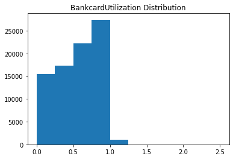

```python
plt.hist(data = filtered_df, x = 'BankcardUtilization');
plt.title("BankcardUtilization Distribution");
```

We can see that the are some outliers in BankcardUtilization where the values are greater than one so we should trim the distribution from 0 to 1 , So I will trim the distribution in the next cell

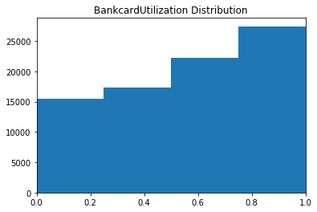

```python
plt.hist(data = filtered_df, x = 'BankcardUtilization');
plt.xlim(0,1);
plt.title("BankcardUtilization Distribution");
```

After trimming the distribution , We can see that the distribution is left-skewed , where the frequency increase as we go from 0 to 1

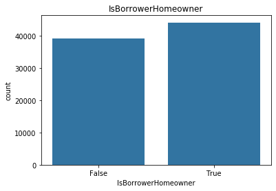

```python
sb.countplot(data=filtered_df, x='IsBorrowerHomeowner', color=base_color);
plt.title("IsBorrowerHomeowner");
```

We can see from the figure above that people that owns home are slight more than the people who don't own a home

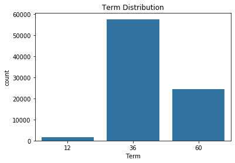

```python
sb.countplot(data=filtered_df, x='Term', color=base_color);
plt.title("Term Distribution");
```

We can see from the figure above that the most frequent term is 36 month than 60 month than 12 months

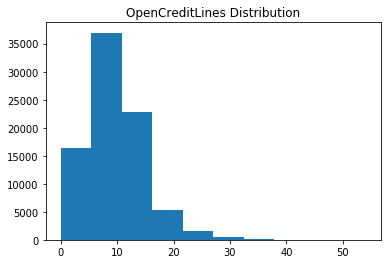

```python
plt.hist(data = filtered_df, x = 'OpenCreditLines');
plt.title("OpenCreditLines Distribution");
```

We can see that the distribution of OpenCreditlines is skewed to the right

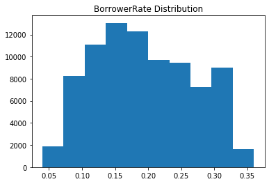

```python
plt.hist(data = filtered_df, x = 'BorrowerRate');
plt.title("BorrowerRate Distribution");
```

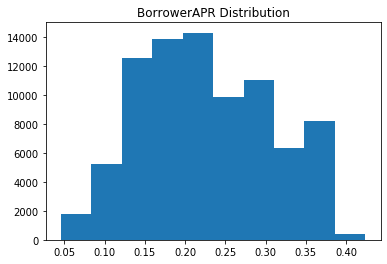

```python
plt.hist(data = filtered_df, x = 'BorrowerAPR');
plt.title("BorrowerAPR Distribution");
```

We can see that the distribution of BorrowerRate and BorrowerAPR variables are almost normal distributed

### Discuss the distribution(s) of your variable(s) of interest. Were there any unusual points? Did you need to perform any transformations?

> The Prosper rating and Prosper Score variables seems to look as a normal distribution and also the Prosper Score looks as a multimodal distribution as there are 3 peeks

## Bivariate Exploration

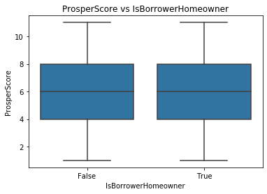

```python
sb.boxplot(data=filtered_df, x='IsBorrowerHomeowner', y='ProsperScore', color=base_color);
plt.title("ProsperScore vs IsBorrowerHomeowner");
```

We can see from the figure above that the two box plots that describes the ProsperScore for both kinds of people who owns home and who don't are almost similar But lets investigate more about those two attributes in the next cell

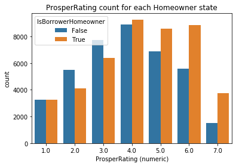

```python
sb.countplot(data = filtered_df, x = 'ProsperRating (numeric)', hue = 'IsBorrowerHomeowner');
plt.title("ProsperRating count for each Homeowner state");
```

We can see from the clustered bar chart above that people who aren't home owner are more than those who are Home owner from rating (1 to 3) and we can see the opposite from ratings(4 to 7) and that make sense that people who have higher ratings tends to own a home

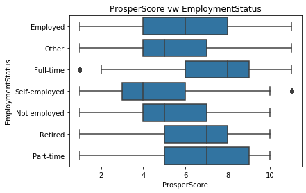

```python
sb.boxplot(data=filtered_df, y='EmploymentStatus', x='ProsperScore', color=base_color);
plt.title("ProsperScore vw EmploymentStatus");
```

From the figure above we can see that the Full time status has the largest prosper score median among all other status , We can see also that both full time and self-employed status have outliers , But the box plots shows us only some summary statistic but it doesn't show us the distribution so lets look at the distribution of prosper score for each EmploymentStatus in the next figure

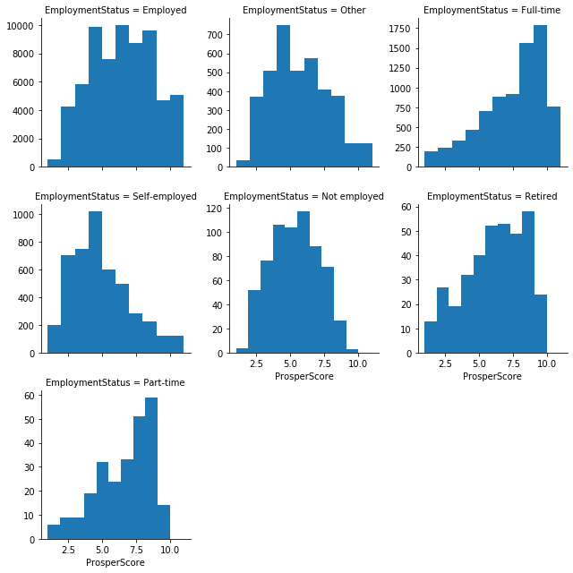

```python
g = sb.FacetGrid(data = filtered_df, col = 'EmploymentStatus', col_wrap=3, sharey=False)
g.map(plt.hist, 'ProsperScore');
```

From the figure above we can see the distribution of ProsperScore for each EmploymentStatus

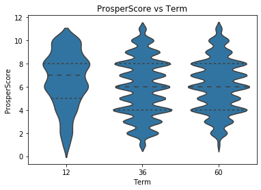

```python
sb.violinplot(data=filtered_df, x='Term', y='ProsperScore', color=base_color,inner='quartile');
plt.title("ProsperScore vs Term");
```

From the figure above we can see the distribution of ProsperScore for each Term and we can also see that the people with 12 month term has the largest ProsperScore median

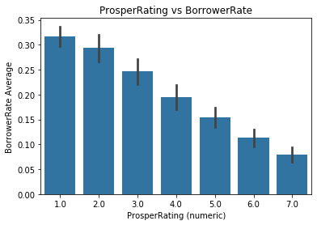

```python
sb.barplot(data=filtered_df, x='ProsperRating (numeric)', y='BorrowerRate', color=base_color,ci='sd');
plt.ylabel('BorrowerRate Average');
plt.title("ProsperRating vs BorrowerRate");
```

We can conclude from the figure above that the average of the Borrower interest rate of the loan (BorrowerRate average) decreases as the ProsperRating increases

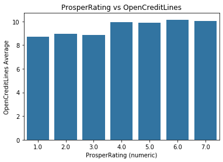

```python
sb.barplot(data=filtered_df, x='ProsperRating (numeric)', y='OpenCreditLines', color=base_color,errwidth=0);
plt.ylabel('OpenCreditLines Average');
plt.title("ProsperRating vs OpenCreditLines");
```

We can conclude from the figure above that people with higher rating have higher Open credit lines on average than people with lower rating

### Did you observe any interesting relationships between the other features (not the main feature(s) of interest)?

No I didn't

## Multivariate Exploration

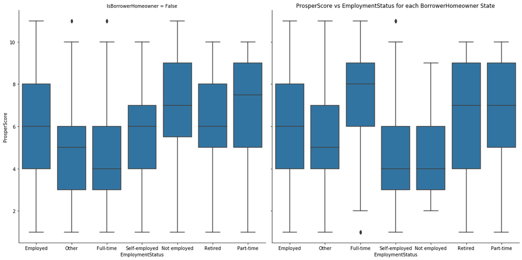

```python
g = sb.FacetGrid(data = filtered_df, col = 'IsBorrowerHomeowner', height = 8,
                margin_titles = True);
g.map(sb.boxplot, 'EmploymentStatus', 'ProsperScore');

plt.title("ProsperScore vs EmploymentStatus for each BorrowerHomeowner State");
```

The figure above show us a box plot for each employment status with the prosperscore for each type of Borrower( Home owner or not) we can see that people who owns home and works us a full time have the highest ProsperScore median

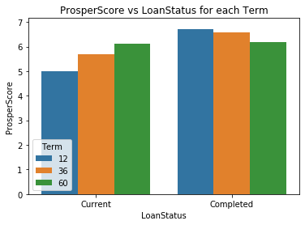

```python
new_df=filtered_df.query('LoanStatus == "Current" or LoanStatus == "Completed"');
sb.barplot(data = new_df, x = 'LoanStatus', y = 'ProsperScore', hue = 'Term',errwidth=0);
plt.title("ProsperScore vs LoanStatus for each Term");
```

We can conclude from the figure above that people with current loan status their average prosperscore increases when the term increases while people with completed loan status are exactly the opposite

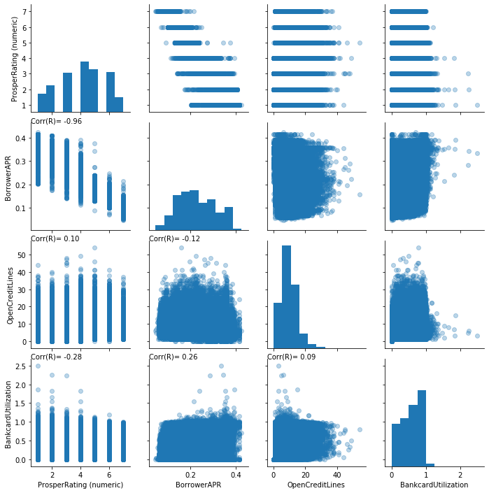

```python
from scipy import stats
def calc_r(x,y,**kws):
    r,_=stats.pearsonr(x,y)
    ax=plt.gca()
    ax.annotate("Corr(R)= {:.2f}".format(r),xy=(0,1),xycoords=ax.transAxes)
g = sb.PairGrid(data = filtered_df, vars = ['ProsperRating (numeric)','BorrowerAPR', 'OpenCreditLines', 'BankcardUtilization'])
g.map_diag(plt.hist);
g.map_offdiag(plt.scatter,alpha=0.3);
g.map_lower(calc_r);
#print(filtered_df['ProsperRating (numeric)'].corr(filtered_df['BorrowerAPR']))
```

We can see from the above pairplot that there are a strong negative correlation between Prosper rating and Borrower ARP where all the other relationships are weak

### Talk about some of the relationships you observed in this part of the investigation. Were there features that strengthened each other in terms of looking at your feature(s) of interest?

we can see that people who owns home and works us a full time have the highest ProsperScore median and that make sense and also we can conclude that people with current loan status their average prosperscore increases when the term increases while people with completed loan status are exactly the opposite

### Were there any interesting or surprising interactions between features?

When doing pairplot I discovered that there are a very strong negative correlation between ProsperRating and BorrowerAPR